# housing

## Introduction

This analysis investigates whether the 2008 crash fundamentally altered housing dynamics, leading to increased instability and homelessness. Using American Community Survey (ACS) microdata, inflation-adjusted home values, and property tax records, we assess changes in homeownership rates, rental burdens, and displacement risk across different counties. Methods

The data used in this analysis came from two sources. First, ACS data sourced from the IPUMS database provided demographic, housing, and economic characteristics of households in California between 2006 and 2014. This data was used to construct housing burden, which is the ratio of monthly housing costs to monthly household income, and the target variable, displacement risk, was then calculated using housing burden. The target is a binary variable, indicating if either: 1) the household’s housing burden is greater than 40% of their monthly income, or 2) the household rents and reports paying $0 in rent (a proxy for housing instability).

In addition to the individual-level survey data, we included countywide property tax revenues as reported by the State of California. In California, property tax assessments are directly tied to purchase prices and are generally stable unless a property is sold or refinanced, due to Proposition 13, which caps annual tax assessment increases at 2% unless a property changes ownership. Therefore, high year-to-year fluctuations in property tax revenues suggest periods of high sales rates. By comparing changes in property taxes to home values and rents, we can have a better picture of the local housing market that year.

For modeling, we aggregated the data by county and year and included the Census Bureau-calculated household weights to calculate median household income, mortgage and rent payments, and housing burden, as well as the relative proportion of homeowners, renters, and households at risk of displacement. We also calculated the year-to-year changes in property tax revenue and median home values.

We first constructed a logistic regression modeling the probability of displacement risk $$P(\text{Displacement Risk}) = \frac{1}{1+e^{-z}}$$ with $z = \beta_{0} + \beta_{1} \text{Ownership} + \beta_{2} \text{Tax Change} + \beta_{3} \text{Median Home Value Change} + \beta_{4} \text{New Residents} + \beta_{5} \text{Post2008} + \beta_{6} \alpha_{c} + \epsilon$

Where:

- Ownership is the weighted proportion of homeowners in the county
- Tax Change is the relative percent change in property taxes
- Median Home Value Change is the relative change in median home value
- New Residents is the weighted proportion of households that moved in the year or or one year before their survey
- Post2008 is a binary indicator for years after 2008
- $\alpha_{c}$ represents county fixed effects
- $\epsilon$ is errors

## Formatting and Cleaning Data

IPUMS provides all data in encoded values - which is helpful for modeling, but not as helpful for exploring the data. Luckily the data comes with xml codebooks that can be used to automate decoding the data. So my first step will be to format the codebooks into usable dictionaries, then use a function to apply those dictionary mappings to the data.

```python
import pandas as pd
import re
from xml.etree import ElementTree as ET
import warnings
import numpy as np
import matplotlib.pyplot as plt
import seaborn as sns

warnings.filterwarnings("ignore", category=pd.errors.SettingWithCopyWarning)
```

```python
acs_codes = ET.parse('usa_00043_codebook.xml').getroot().find('{ddi:codebook:2_5}dataDscr')
acs_codebook = {}
for child in acs_codes:
    if child.get('ID') not in ['SERIAL', 'YEAR', 'SAMPLE', 'STATEFIP', 'COUNTYFIP', 'CPUMA0010', 'RENTGRS', 'FAMSIZE', 'NCHILD', 'AGE', 'IND']:
        name = child.get('ID')
        codes = child.findall('{ddi:codebook:2_5}catgry')
        if len(codes) > 1:
            acs_codebook[name] = {}
            for code in codes:
                cat = code[0].text
                val = code[1].text
                if re.sub(r'\d+', '', cat) == '':
                    cat = int(cat)
                acs_codebook[name][cat] = val
```

```python
cps_codes = ET.parse('cps_00025_codebook.xml').getroot().find('{ddi:codebook:2_5}dataDscr')
cps_codebook = {}
for child in cps_codes:
    if child.get('ID') not in ['MONTH', 'ASECFLAG', 'HFLAG', 'STATEFIP', 'RENTGRS', 'FAM_SIZE', 'NCHILD', 'AGE', 'IND']:
        name = child.get('ID')
        codes = child.findall('{ddi:codebook:2_5}catgry')
        if len(codes) > 1:
            cps_codebook[name] = {}
            for code in codes:
                cat = code[0].text
                val = code[1].text
                if re.sub(r'\d+', '', cat) == '':
                    cat = int(cat)
                cps_codebook[name][cat] = val
```

```python
acs = pd.read_csv('usa_00043.csv')
cps = pd.read_csv('cps_00025.csv')
```

```python
def column_encoder(column, codebook):
    if column.name in codebook.keys():
        return column.map(codebook[column.name])
    else:
        return column

acs = acs.apply(lambda x: column_encoder(x, acs_codebook))
cps = cps.apply(lambda x: column_encoder(x, cps_codebook))
```

```python
acs = acs.loc[acs['RELATE'].isin(['Head/Householder', 'Spouse', 'Partner, friend, visitor', 'Other non-relatives'])]
```

In some households with one individual, the household income variable is missing (9999999), but their income is given in INCTOT (total income). I will replace the missing values in HINCP with the values from INCTOT.

```python
acs.loc[acs['INCTOT'] == 9999999, 'INCTOT'] = 0
acs.loc[acs['INCWELFR'] == 99999, 'INCWELFR'] = 0
```

```python
cps.loc[cps['INCTOT'] >= 99999998, 'INCTOT'] = 0
cps.loc[cps['INCWELFR'] >= 999998, 'INCWELFR'] = 0
cps.loc[cps['INCRETIR'] >= 99999998, 'INCRETIR'] = 0
cps.loc[cps['INCSSI'] >= 999998, 'INCSSI'] = 0
cps.loc[cps['INCUNEMP'] >= 999998, 'INCUNEMP'] = 0
```

```python
acs.loc[acs['HHINCOME'] == 9999999, 'HHINCOME'] = acs.loc[acs['HHINCOME'] == 9999999, 'INCTOT']
cps.loc[cps['HHINCOME'] == 9999999, 'HHINCOME'] = cps.loc[cps['HHINCOME'] == 9999999, 'INCTOT']
```

To have comparable values, I will also need to adjust all monetary amounts for inflation. I will use the CPI from 1999 as a base.

```python
# adjust for inflation
for col in ['MORTAMT1', 'RENTGRS', 'HHINCOME', 'INCTOT', 'INCWELFR']:
    acs[col] = acs[col] / acs['CPI99']

for col in ['HHINCOME', 'INCTOT', 'INCWELFR', 'INCRETIR', "INCSSI", 'INCUNEMP']:
    cps[col] = cps[col] / cps['CPI99']
```

```python
cps.loc[cps['UHRSWORKLY'] == 999, 'UHRSWORKLY'] = 0
```

### Measures of Housing Instability

| Metric | Label | Definition | Population |
| --- | --- | --- | --- |
| Mortgage to Income Ratio | MIR | Mortgage payments (MORTAMT1) divided by household income (HHINCOME) | Households with mortgages |
| Rent to Income Ratio | RIR | Rent (RENTGRS) divided by HHINCOME | Renters, household |
| % New Residents | NRR | % of individuals who moved between PUMAs and/or states last year | metropolitan area |
| Rent to Owner Shift | ROS | % change in share of renters versus owners | metropolitan area |
| Income to Family Size Ratio | IFR | HHINCOME divided by Family size (FAMSIZE) | household |

```python
mortgages = acs.loc[acs['MORTGAGE'].str.startswith('Yes')].groupby(['SAMPLE', 'CBSERIAL']).agg({'HHINCOME': 'max', 'MORTAMT1': 'max'}).reset_index()
mortgages['MIR'] = (mortgages['MORTAMT1'] * 12) / mortgages['HHINCOME']
mortgages.loc[mortgages['MIR'] == np.inf, 'MIR'] = mortgages.loc[mortgages['MIR'] == np.inf].apply(lambda x: 0 if x['HHINCOME'] == 0 else x['MORTAMT1'] / x['HHINCOME'], axis=1)
mortgages.loc[mortgages['MIR'].isna(), 'MIR'] = 0
```

```python
renters = acs.loc[acs['OWNERSHP'] == 'Rented'].groupby(['SAMPLE', 'CBSERIAL']).agg({'HHINCOME': 'max', 'RENTGRS': 'max'}).reset_index()
renters['RIR'] = (renters['RENTGRS'] * 12) / renters['HHINCOME']
renters.loc[renters['RIR'] == np.inf, 'RIR'] = renters.loc[renters['RIR'] == np.inf].apply(lambda x: 0 if x['RENTGRS'] == 0 else x['RENTGRS'] / 1, axis=1)
renters.loc[renters['RIR'].isna(), 'RIR'] = 0
```

```python
new_residents = acs[['SAMPLE', 'CBSERIAL', 'YEAR', 'HHWT', 'MET2013', 'MIGRATE1D']].drop_duplicates()
new_residents['migrate'] = (new_residents['MIGRATE1D'].isin(['Different house, moved within state, between PUMAs', 'Moved between non-contiguous states', 'Moved between contiguous states'])).astype(int)
new_res_met = new_residents.groupby(['YEAR', 'MET2013']).apply(
    lambda x: (x['migrate'] * x['HHWT']).sum() / x['HHWT'].sum()
).reset_index(name='nrr')
```

```python
housing = acs[['SAMPLE', 'CBSERIAL', 'YEAR', 'HHWT', 'MET2013', 'OWNERSHP']].drop_duplicates()
housing['renter'] = (housing['OWNERSHP'] == 'Rented').astype(int)
housing['owner'] = (housing['OWNERSHP'] == 'Owned or being bought (loan)').astype(int)
weighted_housing = housing.groupby(['YEAR', 'MET2013']).apply(
    lambda x: (x['renter'] * x['HHWT']).sum() / (x['owner'] * x['HHWT']).sum()
).reset_index(name='ROS')
```

```python
income_housing = acs.drop_duplicates(subset=['SAMPLE', 'CBSERIAL', 'FAMSIZE'])
income_housing['IFR'] = income_housing['HHINCOME'] / income_housing['FAMSIZE']
```

```python
full_acs = acs.merge(mortgages, on=['SAMPLE', 'CBSERIAL'], how='left', suffixes=('', '_m')).drop(columns=['HHINCOME_m', 'MORTAMT1_m']).merge(renters, on=['SAMPLE', 'CBSERIAL'], how='left', suffixes=('', '_r')).drop(columns=['HHINCOME_r']).merge(new_res_met, on=['YEAR', 'MET2013'], how='left', suffixes=('', '_nrm')).merge(weighted_housing, on=['YEAR', 'MET2013'], how='left', suffixes=('', '_ros')).merge(income_housing, on=['SAMPLE', 'CBSERIAL'], how='left', suffixes=('', '_if')).drop(columns=['FAMSIZE_if'])
```

```python
full_acs = full_acs.loc[~(full_acs['MIR'].isna() & full_acs['RIR'].isna())]
```

### Aggregating the Data

The datasets share ['METRO', 'OWNERSHP', 'HHINCOME', 'NFAMS', 'FAMSIZE', 'NCHILD', 'SEX', 'AGE', 'MARST', 'RACE', 'HISPAN', 'EDUC', 'EMPSTAT', 'IND', 'INCTOT', 'INCWELFR', 'MIGRATE1', 'YEAR'] in common. They also have the same values for employed last year, county and metropolitan area, but these features need to be cleaned a bit before being similar. Some of the variable definitions are similar, but not exactly the same, so I will also be cleaning those up a bit. Because a lot of the values are so similar, or essentially the same just described differently, I will be manually cleaning up these shared features.

```python
# simplifying worked last year values
full_acs.loc[full_acs['WORKEDYR'].str.startswith('No'), 'WORKLY'] = 'No'
full_acs.loc[full_acs['WORKEDYR'] == 'N/A', 'WORKLYR'] = 'NIU'
full_acs.loc[full_acs['WORKEDYR'] == 'Yes', 'WORKLY'] = 'Yes'
```

```python
# removing state number from the  county number
cps['COUNTYFIP'] = cps['COUNTY'].apply(lambda x: int(re.sub(r'^60*', '', str(x))))
```

```python
cps['METRO'].value_counts()
```

```
METRO
In central/principal city                       81370
Not in central/principal city                   79770
Central/principal city status not identified    15469
Not in metropolitan area                         2791
Name: count, dtype: int64
```

```python
full_acs['METRO'].value_counts()
```

```
METRO
In metropolitan area: Central/principal city status indeterminable (mixed)    654593
In metropolitan area: Not in central/principal city                           652996
In metropolitan area: In central/principal city                               350281
Not in metropolitan area                                                       49881
Metropolitan status indeterminable (mixed)                                      5857
Name: count, dtype: int64
```

```python
# re-wording metropolitan status
acs_metro = {
    'In metropolitan area: Central/principal city status indeterminable (mixed)': 'Central/principal city status not identified',
    'In metropolitan area: Not in central/principal city': 'Not in central/principal city',
    'In metropolitan area: In central/principal city': 'In central/principal city',
    'Not in metropolitan area': 'Not in metropolitan area',
    'Metropolitan status indeterminable (mixed)': 'Not in metropolitan area'
}
full_acs['METRO'] = full_acs['METRO'].map(acs_metro)
```

One of the more important (but also more challenging) variables I need to standardize is the code for the metropolitan area. In the ACS dataset, the values were provided in their 2013 forms across the board. However the CPS data is not as consistent, and also does not provide the area names in its codebook. Therefore using the ACS codebook and the values I have, I will convert all of the metropolitan areas to their 2013 codes and ensure I can access their correct names.

```python
# gather all codes and names available in acs data
met_codes = full_acs[['COUNTYFIP', 'MET2013', 'METRO']].drop_duplicates()
reverse_met13 = {v:k for k, v in acs_codebook['MET2013'].items()}
for i, row in met_codes.iterrows():
    met_codes.loc[i, 'MET2013_code'] = reverse_met13[row['MET2013']]
```

```python
# create a set of unique combinations of county code, met code, and metro status
cps_metcodes = cps.loc[cps['METFIPS'].isin(met_codes['MET2013_code']), ['COUNTYFIP', 'METFIPS']].merge(met_codes, left_on=['COUNTYFIP', 'METFIPS'], right_on=['COUNTYFIP', 'MET2013_code'], how='left').drop_duplicates()[['COUNTYFIP', 'METFIPS', 'MET2013', 'METRO']]
```

This merge leaves some empty values, but since there are so few I can manually repair them using the [CPS METFIPS codes](https://www2.census.gov/programs-surveys/cps/methodology/2015%20Geography%20Cover.pdf).

```python
cps_metcodes.loc[(cps_metcodes['COUNTYFIP'] == 53) & (cps_metcodes['METFIPS'] == 41500), 'MET2013'] = 'Salinas, CA'
cps_metcodes.loc[cps_metcodes['METFIPS'] == 41860, 'MET2013'] = 'San Francisco-Oakland-Hayward, CA'
cps_metcodes.loc[cps_metcodes['METFIPS'] == 41940, 'MET2013'] = 'San Jose-Sunnyvale-Santa Clara, CA'
```

There are still some areas that aren't included in the ACS data (probably because they use the pre-2013 codes). There are also very few of these, so again it's easiest to manually repair them.

```python
met_extras = cps.loc[~cps['METFIPS'].isin(cps_metcodes['METFIPS']), ['COUNTYFIP', 'METRO', 'METFIPS']].drop_duplicates() # manually update extras
```

```python
met_extras.loc[met_extras['METFIPS'] == 31100, 'MET2013'] = 'Los Angeles-Long Beach-Anaheim, CA'
met_extras.loc[met_extras['METFIPS'] == 42060, 'MET2013'] = 'Santa Maria-Santa Barbara, CA'
met_extras.loc[met_extras['METFIPS'] == 99998, 'MET2013'] = 'Not in identifiable area'
```

```python
combined_metcodes = pd.concat([cps_metcodes, met_extras], ignore_index=True)[['METFIPS', 'MET2013']].drop_duplicates().set_index('METFIPS').to_dict()['MET2013']
cps['MET2013'] = cps['METFIPS'].map(combined_metcodes)
```

```python
cps.loc[cps['OWNERSHP'] == 'Owned or being bought', 'OWNERSHP'] = 'Owned or being bought (loan)'
cps.loc[cps['OWNERSHP'].str.contains('cash rent'), 'OWNERSHP'] = 'Rented'
cps.loc[~cps['OWNERSHP'].isin(['Owned or being bought (loan)', 'Rented']), 'OWNERSHP'] = 'N/A'
```

```python
full_acs['RACE'].value_counts()
```

```
RACE
White                               1130370
Other race, nec                      187648
Other Asian or Pacific Islander      162890
Black/African American                89693
Chinese                               63318
Two major races                       44854
Japanese                              16206
American Indian or Alaska Native      14307
Three or more major races              4322
Name: count, dtype: int64
```

```python
cps['RACE'].value_counts()
```

```
RACE
White                                              138539
Asian only                                          22276
Black                                               10723
American Indian/Aleut/Eskimo                         1869
White-Asian                                          1485
White-American Indian                                1428
Hawaiian/Pacific Islander only                       1374
White-Black                                           758
White-Hawaiian/Pacific Islander                       206
White-Black-American Indian                           168
Black-American Indian                                 160
Black-Asian                                           119
Asian-Hawaiian/Pacific Islander                        81
Two or three races, unspecified                        49
White-American Indian-Asian                            47
Black-Hawaiian/Pacific Islander                        33
White-Asian-Hawaiian/Pacific Islander                  25
White-Black-Asian                                      23
American Indian-Asian                                  15
White-Black-American Indian-Asian                      12
White-Black--Hawaiian/Pacific Islander                  5
Four or five races, unspecified                         4
White-American Indian-Hawaiian/Pacific Islander         1
Name: count, dtype: int64
```

```python
full_acs.loc[full_acs['RACE'] == 'Black/African American', 'RACE'] = 'Black'
full_acs.loc[full_acs['RACE'].isin(['Chinese', 'Japanese', 'Other Asian or Pacific Islander']), 'RACE'] = 'Asian or pacific islander'
full_acs.loc[full_acs['RACE'] == 'Other race, nec', 'RACE'] = 'Three or more major races'
```

```python
cps_race = {
    'Asian only': 'Asian or pacific islander',
    'American Indian/Aleut/Eskimo': 'American Indian or Alaska Native',
    'Hawaiian/Pacific Islander only': 'Asian or pacific islander',
    'White': 'White',
    'Black': 'Black',
    'Two or three races, unspecified': 'Two major races',
    'Four or five races, unspecified': 'Three or more major races',
}

multiple_races = cps['RACE'].value_counts().reset_index().loc[lambda x: ~x['RACE'].isin(cps_race.keys())]
for _, row in multiple_races.iterrows():
    races = row['RACE'].split('-')
    if len(races) == 2:
        cps_race[row['RACE']] = 'Two major races'
    elif len(races) >= 3:
        cps_race[row['RACE']] = 'Three or more major races'

cps.loc[cps['RACE'].isin(cps_race.keys()), 'RACE'] = cps.loc[cps['RACE'].isin(cps_race.keys()), 'RACE'].map(cps_race)
```

```python
cps.loc[cps['HISPAN'] != 'Not Hispanic', 'race_hispanic'] = 'Hispanic'
cps.loc[cps['race_hispanic'].isnull(), 'race_hispanic'] = cps.loc[cps['race_hispanic'].isnull(), 'RACE']
```

```python
full_acs.loc[full_acs['HISPAN'] != 'Not Hispanic', 'race_hispanic'] = 'Hispanic'
full_acs.loc[full_acs['race_hispanic'].isnull(), 'race_hispanic'] = full_acs.loc[full_acs['race_hispanic'].isnull(), 'RACE']
```

```python
cps['EMPSTAT'].value_counts()
```

```
EMPSTAT
At work                           76494
NIU                               42431
NILF, other                       28401
NILF, retired                     15821
Unemployed, experienced worker     7243
NILF, unable to work               5560
Has job, not at work last week     2210
Unemployed, new worker              796
Armed Forces                        444
Name: count, dtype: int64
```

```python
full_acs['EMPSTAT'].value_counts()
```

```
EMPSTAT
Employed              1137792
Not in labor force     469813
Unemployed              88834
N/A                     17169
Name: count, dtype: int64
```

```python
cps_emp = {
    'At work': 'Employed',
    'NIU': 'N/A',
    'NILF, other': 'Not in labor force',
    'NILF, retired': 'Not in labor force',
    'NILF, unable to work': 'Not in labor force',
    'Unemployed, experienced worker': 'Unemployed',
    'Unemployed, new worker': 'Unemployed',
    'Has job, not at work last week': 'Employed',
    'Armed Forces': 'Employed'
}
cps['EMPSTAT'] = cps['EMPSTAT'].map(cps_emp)
```

```python
cps['MIGRATE1'].value_counts()
```

```
MIGRATE1
Same house                              158637
Moved within county                      13599
Moved within state, different county      2998
NIU                                       2188
Moved between states                      1300
Abroad                                     678
Name: count, dtype: int64
```

```python
full_acs['MIGRATE1'].value_counts()
```

```
MIGRATE1
Same house              1456521
Moved within state       220974
Moved between states      22840
Abroad one year ago       12227
N/A                        1046
Name: count, dtype: int64
```

```python
cps_migrate = {
    'Same house': 'Same house',
    'Moved within county': 'Moved',
    'Moved within state, different county': 'Moved',
    'NIU': 'N/A',
    'Moved between states': 'Moved',
    'Abroad': 'N/A'
}
cps['MIGRATE1'] = cps['MIGRATE1'].map(cps_migrate)
```

```python
acs_migrate = {
    'Same house': 'Same house',
    'Moved within state': 'Moved',
    'Moved between states': 'Moved',
    'Abroad one year ago': 'N/A',
    'N/A': 'N/A'
}
full_acs['MIGRATE1'] = full_acs['MIGRATE1'].map(acs_migrate)
```

```python
cps['nchild'] = cps['NCHILD'].apply(lambda x: '0' if x == 0 else '1' if x == 1 else '2' if x == 2 else '3' if x == 3 else '4+')
```

```python
full_acs['nchild'] = full_acs['NCHILD'].apply(lambda x: '0' if x == 0 else '1' if x == 1 else '2' if x == 2 else '3' if x == 3 else '4+')
```

```python
cps_common = cps.groupby(['METRO', 'nchild', 'MET2013', 'race_hispanic', 'EMPSTAT', 'MIGRATE1', 'WORKLY', 'YEAR']).agg({
    'HEALTH': lambda x: pd.Series(x).mode().iloc[0],
    'RENTSUB': lambda x: np.average(x == 'Yes', weights=cps.loc[x.index, 'ASECWTH']),
    'FOODSTMP': lambda x: np.average(x == 'Yes', weights=cps.loc[x.index, 'ASECWTH']),
    'WHYNWLY': lambda x: pd.Series(x).mode().iloc[0],
    'WHYUNEMP': lambda x: pd.Series(x).mode().iloc[0]
}).reset_index()
```

```python
acs_common = full_acs.groupby(['METRO', 'nchild', 'MET2013', 'race_hispanic', 'EMPSTAT', 'MIGRATE1', 'WORKLY', 'YEAR']).agg({
    'HHINCOME': lambda x: np.average(x, weights=full_acs.loc[x.index, 'HHWT']),
    'MIR': lambda x: np.average(x, weights=full_acs.loc[x.index, 'HHWT']),
    'RIR': lambda x: np.average(x, weights=full_acs.loc[x.index, 'HHWT']),
    'nrr': lambda x: np.average(x, weights=full_acs.loc[x.index, 'HHWT']),
    'ROS': lambda x: np.average(x, weights=full_acs.loc[x.index, 'HHWT']),
    'FAMSIZE': lambda x: np.average(x, weights=full_acs.loc[x.index, 'HHWT']),
    'HHWT': 'mean'
}).reset_index()
```

```python
shared_cols = [c for c in cps_common.columns if c in acs_common.columns]
common = acs_common.merge(cps_common, on=shared_cols, suffixes=('', ''), how='inner')
```

```python
common_df = common.loc[~common['MET2013'].isin(['El Centro, CA', 'Santa Rosa, CA', 'Visalia-Porterville, CA'])]
```

## Analysis

### Time Trends

Before investigating any relationships, let's first look at the time trends contained in the combined data.

```python
data = common_df.groupby(['YEAR', 'MET2013']).agg({'HHINCOME': lambda x: np.average(x, weights=common_df.loc[x.index, 'HHWT'])}).reset_index()
```

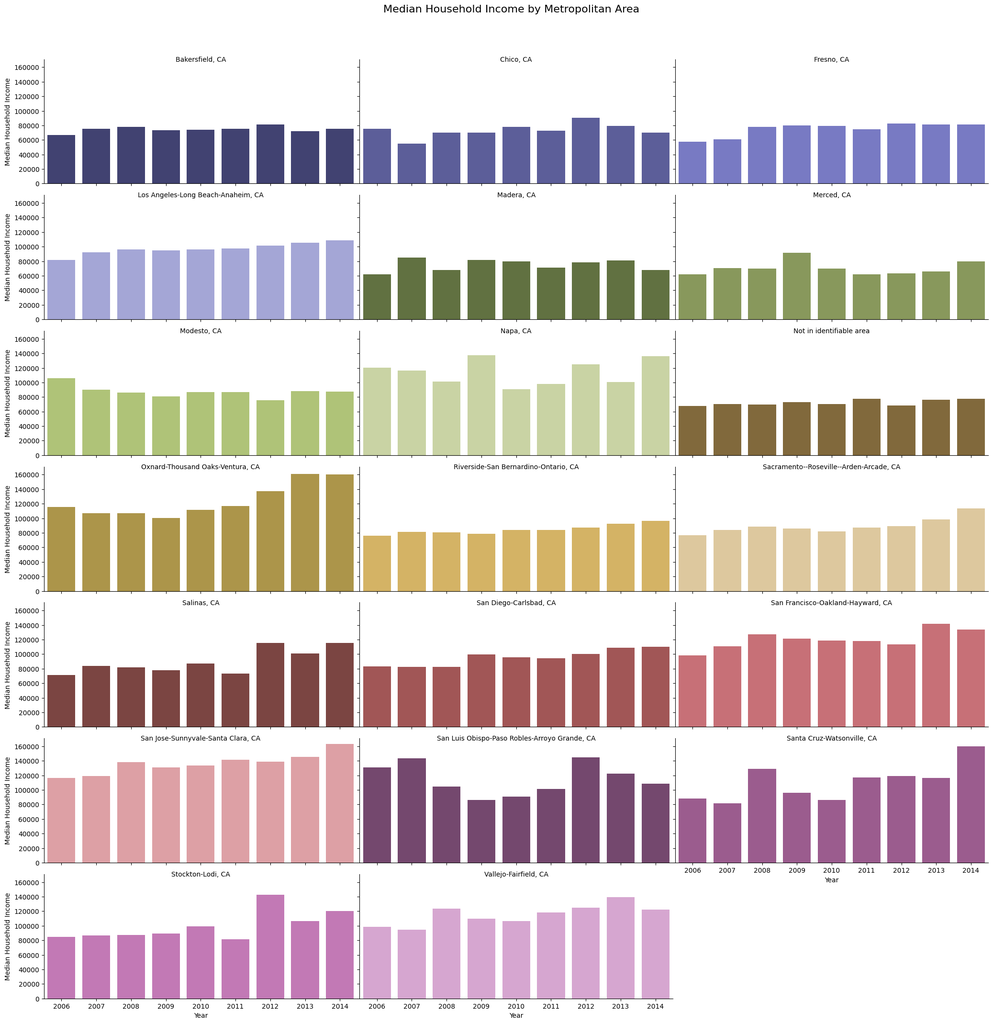

```python
a = sns.catplot(data=data, x='YEAR', y='HHINCOME', col='MET2013', col_wrap=3, kind='bar', height=7, aspect=4, hue='MET2013', palette='tab20b', legend=False)
plt.gcf().set_size_inches(20, 20)
a.set_axis_labels('Year', 'Median Household Income')
a.set_titles('{col_name}', fontsize=14, y=0.95)
plt.suptitle('Median Household Income by Metropolitan Area', fontsize=16, y=1.05)
plt.show()
```

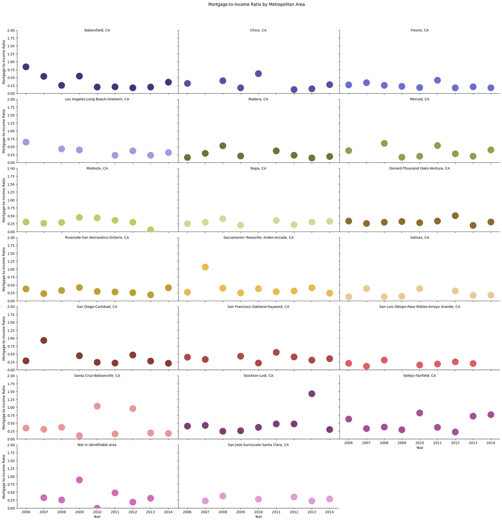

```python
mir_data = common_df.loc[~common_df['MIR'].isna()].groupby(['YEAR', 'MET2013']).agg({"MIR": lambda x: np.average(x, weights=common_df.loc[x.index, 'HHWT'])}).reset_index()
mir_data['MIR'] = mir_data['MIR'].round(2)
b = sns.catplot(data=mir_data, x='YEAR', y='MIR', col='MET2013', col_wrap=3, kind='strip', height=7, aspect=4, hue='MET2013', palette='tab20b', size=20, legend=False)
plt.gcf().set_size_inches(20, 20)
b.set_axis_labels('Year', 'Mortgage-to-Income Ratio')
b.set_titles('{col_name}', fontsize=14, y=0.95)
b.set(ylim=(0, 2))
plt.suptitle('Mortgage-to-Income Ratio by Metropolitan Area', y=1.05)
plt.show()
```

The mortgage to income ratios seem to peak around two points - 2009 and 2014. It seems that they have a downward trend after the housing market crash, but pick up again shortly after. This could be representing peoples' hesitancy to buy a house after the crash, or lenders' hesitancy to lend.

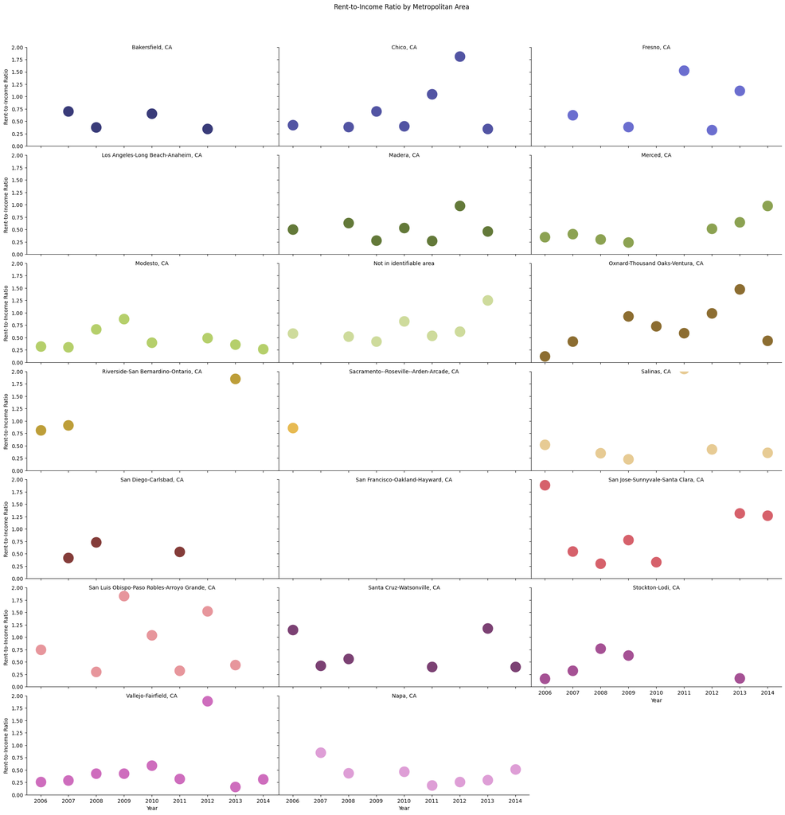

```python
rir_data = common_df.loc[~common_df['RIR'].isna()].groupby(['YEAR', 'MET2013']).agg({"RIR": lambda x: np.average(x, weights=common_df.loc[x.index, 'HHWT'])}).reset_index()
rir_data['RIR'] = rir_data['RIR'].round(2)
c = sns.catplot(data=rir_data, x='YEAR', y='RIR', col='MET2013', col_wrap=3, kind='strip', height=7, aspect=4, hue='MET2013', palette='tab20b', size=20, legend=False)
plt.gcf().set_size_inches(20, 20)
c.set_axis_labels('Year', 'Rent-to-Income Ratio')
c.set_titles('{col_name}', fontsize=14, y=0.95)
c.set(ylim=(0, 2))
plt.suptitle('Rent-to-Income Ratio by Metropolitan Area', y=1.05)
plt.show()
```

These values are a lot more inconsistent, so the results they represent must be taken with a grain of salt. However, they do generally imitate the trends in the mortgage to income ratios, with two peaks around 2009 and 2014, and a decline in between.

```python
com_df = common_df.copy()
com_df['MIR'] = np.ma.masked_where(com_df['MIR'].isna(), com_df['MIR'])
com_df['RIR'] = np.ma.masked_where(com_df['RIR'].isna(), com_df['RIR'])
```

```python
cdf = com_df.groupby(['YEAR', 'MET2013']).agg({
    'EMPSTAT': lambda x: np.average(x == 'Employed', weights=x.index.map(common_df['HHWT'])),
    'WORKLY': lambda x: np.average(x == 'Yes', weights=x.index.map(common_df['HHWT'])),
    'HHINCOME': lambda x: np.average(x, weights=x.index.map(common_df['HHWT'])),
    'nrr': 'mean',
    'ROS': 'mean',
    'HEALTH': lambda x: np.average(x.isin(['Excellent', 'Very good', 'Good']), weights=x.index.map(common_df['HHWT'])),
    'FOODSTMP': lambda x: np.average(x, weights=x.index.map(common_df['HHWT'])),
    'WHYNWLY': lambda x: np.average(x == 'Ill or disabled', weights=x.index.map(common_df['HHWT'])),
    'race_hispanic': lambda x: np.average(x != 'White', weights=x.index.map(common_df['HHWT']))
}).reset_index()
```

```python
differences = cdf.sort_values(['MET2013', "YEAR"], ascending=False).groupby('MET2013')[[c for c in cdf.columns if c not in ['YEAR', 'MET2013']]].diff().assign(
    YEAR=cdf.sort_values(['MET2013', "YEAR"])['YEAR'].values,
    MET2013=cdf.sort_values(['MET2013', "YEAR"])['MET2013'].values
).reset_index(drop=True).loc[lambda x: (x['YEAR'] != 2006) & (x['YEAR'] != 2014)]
```

To identify overall trends, we will visualize the data without metropolitan area names. This way we can identify separate areas, while focusing on the overall patterns in the data.

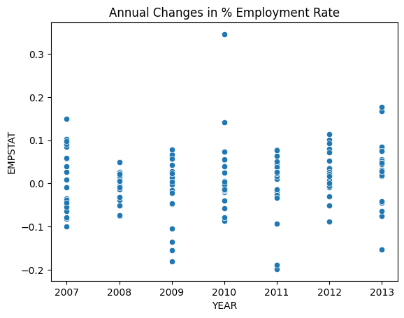

```python
sns.scatterplot(differences, x='YEAR', y='EMPSTAT')
plt.title('Annual Changes in % Employment Rate')
plt.show()
```

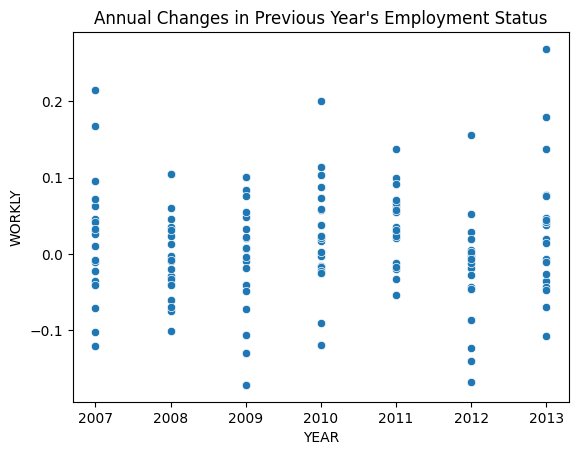

```python
sns.scatterplot(differences, x='YEAR', y='WORKLY')
plt.title('Annual Changes in Previous Year\'s Employment Status')
plt.show()
```

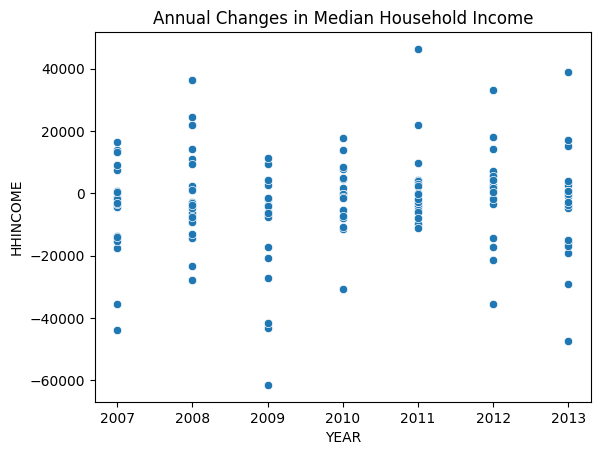

```python
sns.scatterplot(differences, x='YEAR', y='HHINCOME')
plt.title('Annual Changes in Median Household Income')
plt.show()
```

The changes in 2009 seem to be almost the exact opposites of the changes in 2008, showing large decreases in household income.

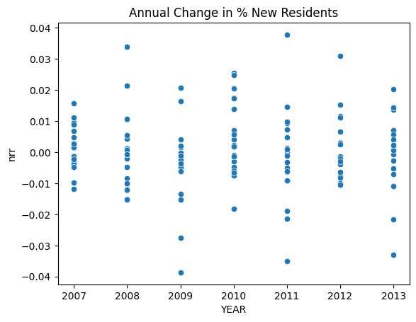

```python
sns.scatterplot(differences, x='YEAR', y='nrr')
plt.title('Annual Change in % New Residents')
plt.show()
```

Ostensibly, 2009 shows a dramatic decrease in the percentage of new residents in the area. However, the values in 2011 are very similar, with a slight increase. It seems that the housing market may have been similar in 2009 and 2011.

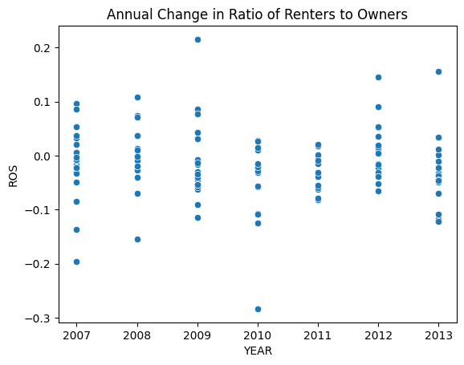

```python
sns.scatterplot(differences, x='YEAR', y='ROS')
plt.title('Annual Change in Ratio of Renters to Owners')
plt.show()
```

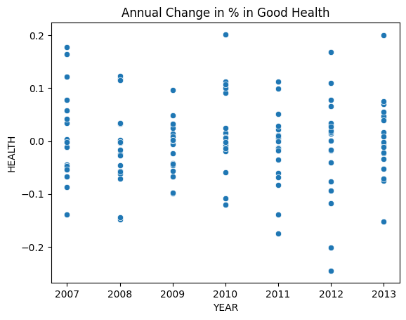

```python
sns.scatterplot(differences, x='YEAR', y='HEALTH')
plt.title('Annual Change in % in Good Health')
plt.show()
```

This variable breaks the trend of the other variables, with a peak in 2011. It seeems that the percentage of people in good health increased between 2008 and 2009, and again between 2010 and 2011. This is a subjective observation, so it could be that people under financial strain were less concerned with other aspects of their health.

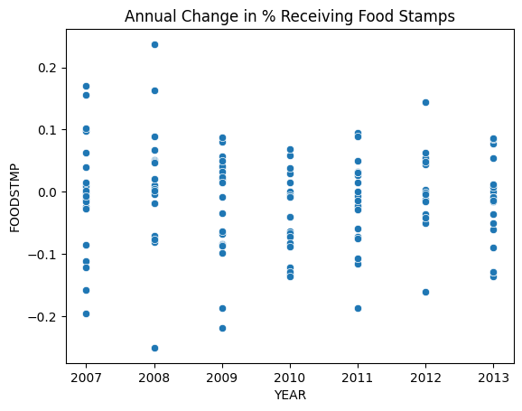

```python
sns.scatterplot(differences, x='YEAR', y='FOODSTMP')
plt.title('Annual Change in % Receiving Food Stamps')
plt.show()
```

Interestingly, the percentage of the population receiving food stamps did not increasae dramatically between 2008 and 2009, but did after 2011. It appears rates were on an increasing trend starting between 2007 and 2008.

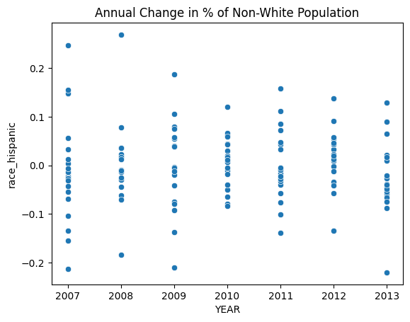

```python
sns.scatterplot(differences, x='YEAR', y='race_hispanic')
plt.title('Annual Change in % of Non-White Population')
plt.show()
```

```python
median_incomes = common_df.groupby(['YEAR', 'MET2013']).agg({'HHINCOME': lambda x: np.average(x, weights=common_df.loc[x.index, 'HHWT'])}).reset_index()
com = common_df.merge(median_incomes, on=['YEAR', 'MET2013'], how='left', suffixes=('', '_median'))
com['dist_from_median'] = com['HHINCOME'] - com['HHINCOME_median']
```

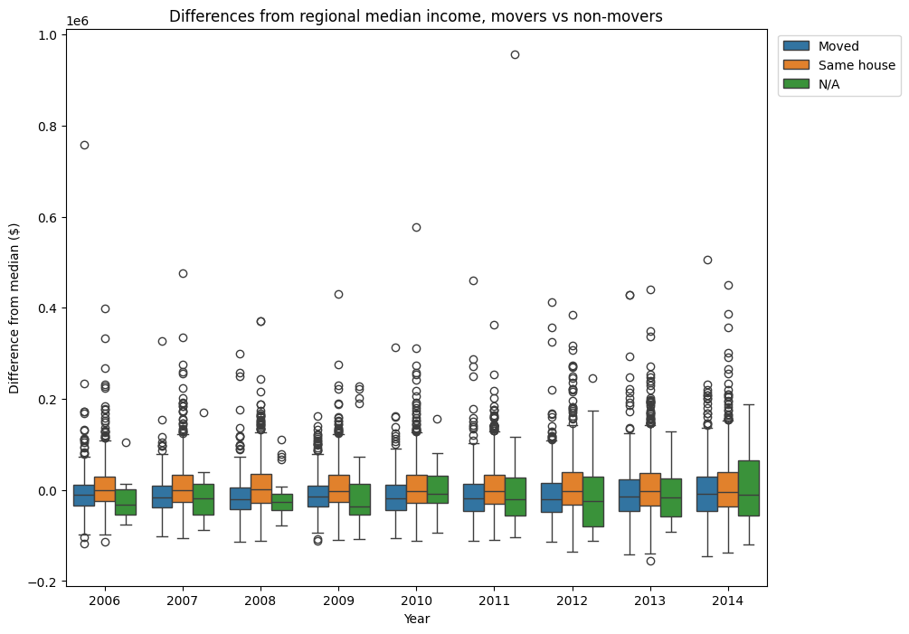

```python
fig, ax = plt.subplots(1, 1, figsize=(10, 8))
sns.boxplot(x='YEAR', y='dist_from_median', data=com, hue='MIGRATE1', ax=ax)
fig.set_size_inches(10, 8)
ax.set_title('Differences from regional median income, movers vs non-movers')
ax.set_xlabel('Year')
ax.set_ylabel('Difference from median ($)')
ax.legend(title=None, loc='upper right', bbox_to_anchor=(1.2, 1))
plt.show()
```

## Part 2

## Data

```python
%load_ext rpy2.ipython
```

```
The rpy2.ipython extension is already loaded. To reload it, use:
  %reload_ext rpy2.ipython
```

```python
%%R
#| echo: false
#| message: false
#| warning: false
#| results: hide
library(readr)
library(stringr)
library(matrixStats)
library(ggtext)
library(gridExtra)
library(grid)
library(tidyverse)
library(sandwich)
library(lmtest)
library(tidyr)
library(fixest)
library(broom)
library(modelsummary)
library(sf)
```

### ACS Data

```python
%%R
acs_data <- read_csv("acs_cleaned.csv")

acs <- acs_data %>%
    filter(RELATE == "Head/Householder") %>%
    mutate(
        # clean income values
        HHINCOME = case_when(
            HHINCOME >= 9999998 & INCTOT > 0 & INCTOT < 9999998 ~ INCTOT,
            HHINCOME >= 9999998 & INCTOT >= 9999998 ~ 0,
            TRUE ~ HHINCOME
        ) / CPI99, # adjust for inflation
        MORTAMT1 = if_else(MORTAMT1 > 0, MORTAMT1 / CPI99, 0),
        RENTGRS = if_else(RENTGRS > 0, RENTGRS / CPI99, 0),
        owner_binary = if_else(startsWith(OWNERSHP, "Owned"), 1, 0), # simplifying home ownership
        post2008 = if_else(YEAR <= 2008, 0, 1), # treatment variable
        rent_binary = if_else(startsWith(OWNERSHP, "Rented"), 1, 0),
        housing_burden = case_when( # ratio of monthly housing cost to monthly household income
            MORTAMT1 > 0 & HHINCOME > 0 ~ MORTAMT1 / (HHINCOME / 12), # mortgage payment
            RENTGRS > 0 & HHINCOME > 0 ~ RENTGRS / (HHINCOME / 12), # rent payment
            MORTAMT1 > 0 & HHINCOME == 0 ~ 1, # if no income, housing burden is 100%
            RENTGRS > 0 & HHINCOME == 0 ~ 1,
            TRUE ~ 0 # no housing cost (i.e. living with family, own home without mortgage, etc.)
        ),
        rural = if_else(METRO == "Not in metropolitan area", 1, 0), # rural area
        urban = if_else(METRO == "In metropolitan area: In central/principal city", 1, 0) # urban area
    ) %>%
    mutate(
        housing_burden = if_else((is.na(housing_burden) | is.infinite(housing_burden)), 0, housing_burden),
        displacement_risk = if_else(
            housing_burden > 0.4 | (rent_binary == 1 & RENTGRS == 0), 1, 0 # if housing cost is more than 40% of monthly income or if renting and rent is 0 (proxy for being unhoused)
        )
    )
```

We start with individual-level ACS data filtered to head-of-household respondents. The following variables are constructed:

- owner_binary: a binary flag that indicates if the respondent owns their home
- post2008: a binary flag that indicates if the survey was responded to after 2008
- rent_binary: a binary flag that indicates if the respondent rents their home
- housing_burden: the ratio of monthly housing cost to monthly household income
- displacement_risk: a binary flag that indicates if the respondent is at risk of displacement. Here this is defined as having a housing cost that is more than 40% of monthly income or if renting and rent is $0 (proxy for being unhoused).
- rural/urban: binary flags that indicate if the respondent lives in a rural or urban area. There are 5 possible metropolitan statuses, so these indicators won't add any redundancy.

### More ACS Data

This secondary ACS dataset from IPUMS provides home value ranges (adjusted for inflation with the 1999 CPI). By converting these bins to numeric midpoints and then aggregating with household weights, we calculated the median home value by county and year. This metric helps contextualize economic conditions—lower median values during the crash may reflect foreclosure-induced declines.

```python
%%R
home_values <- read_csv("home_values.csv")

cpi99 <- acs_data %>%
    select(YEAR, CPI99) %>%
    distinct()

home_values_cleaned <- home_values %>%
    left_join(cpi99, by = "YEAR") %>%
    filter(VALUEH != "N/A") %>%
    mutate( # convert string value bins to numeric midpoints
        home_vales = str_remove_all(VALUEH, "[,\\$\\s]"),
        lowval = as.numeric(str_extract(home_vales, "\\d+(?=\\-)")),
        highval = as.numeric(str_extract(home_vales, "(?<=\\-)\\d+")),
        home_value = (lowval + highval) / 2,
        home_value = home_value / CPI99
    ) %>%
    filter(!is.na(home_value)) %>%
    select(YEAR, home_value, COUNTYFIP, HHWT, CBSERIAL, SAMPLE)
```

```python
%%R
median_values <- home_values_cleaned %>%
    group_by(YEAR, COUNTYFIP) %>%
    summarise(median_home_value = weightedMedian(home_value, HHWT))
```

### property tax data

This is a [dataset](https://data.ca.gov/dataset/property-tax-raw-data-for-fiscal-years-2002-03-to-2018-19/resource/a2c66ed3-e903-4af8-ab4d-75a8ce9a7569) provided by the state of California. It contains records of total property tax revenue for each county, per fiscal year, from 2002 to 2019. Property taxes act as a proxy for property turnover. In California, where taxes are based on the home’s purchase price, significant changes year-over-year indicate frequent changes in ownership. By comparing tax changes with home value declines, we can infer periods where foreclosures and subsequent re-purchases may have driven displacement.

```python
%%R
property_tax <- read_csv("PropertyTax_DataSet_20190513(LG_COUNTYWIDE_PROPTAX).csv") %>%
    select(`Entity Name`, `Fiscal Year`, `Total_Countywide Property Taxes`) %>%
    filter(`Fiscal Year` >= 2006 & `Fiscal Year` <= 2014) %>%
    rename(
        YEAR = `Fiscal Year`,
        county_tax = `Total_Countywide Property Taxes`,
        county = `Entity Name`
    )

county_names <- read_csv("state_and_county_fips_master.csv") %>%
    filter(state == "CA") %>%
    mutate(fips = fips - 6000)
```

### Data Aggregation

```python
%%R
counties <- median_values %>%
    left_join(county_names, by = c("COUNTYFIP" = "fips")) %>%
    select(!state) %>%
    mutate(name = str_replace(name, " County", "")) %>%
    filter(!is.na(name)) %>%
    left_join(property_tax, by = c("YEAR", "name" = "county"))
```

Now, using household level weights, I will calculate median statistics for different housing/economic metrics in each county.

```python
%%R
acs_df <- acs %>%
    filter(COUNTYFIP != 0) %>%
    group_by(YEAR, COUNTYFIP) %>%
    mutate(
        income = weighted.mean(HHINCOME, HHWT),
        ownership = weighted.mean(if_else(startsWith(OWNERSHP, "Owned"), 1, 0), HHWT),
        renters = weighted.mean(if_else(OWNERSHP == "Rented", 1, 0), HHWT),
        housing_burden = weighted.mean(housing_burden, HHWT),
        displacement_risk = weighted.mean(displacement_risk, HHWT),
        new_residents = weighted.mean(if_else(startsWith(MOVEDIN, "This yr"), 1, 0), HHWT),
        median_mortgage = weightedMedian(MORTAMT1[startsWith(MORTGAGE, 'Yes')], HHWT[startsWith(MORTGAGE, 'Yes')]),
        median_rent = weightedMedian(RENTGRS[OWNERSHP == 'Rented'], HHWT[OWNERSHP == 'Rented']),
    ) %>%
    left_join(counties, by = c("YEAR", "COUNTYFIP")) %>%
    ungroup() %>%
    arrange(COUNTYFIP, YEAR) %>%
    group_by(COUNTYFIP) %>%
    mutate(
        tax_change = (county_tax - lag(county_tax)) / lag(county_tax) * 100,
        median_hval_change = (median_home_value - lag(median_home_value)) / lag(median_home_value) * 100
    ) %>%
    filter(name %in% c("San Francisco", "Alameda", 'Marin', 'Napa', 'Contra Costa', 'San Mateo', 'Santa Clara', 'Solano', 'Sonoma') & (!is.na(tax_change) & !is.na(median_hval_change))) %>%
    ungroup() %>%
    group_by(YEAR, name) %>%
    select(tax_change, median_hval_change, ownership, housing_burden, displacement_risk, new_residents, median_mortgage, median_rent, income) %>%
    distinct() %>%
    filter(tax_change != 0 & median_hval_change != 0) %>%
    ungroup() %>%
    mutate(
        post_2008 = if_else(YEAR > 2008, 1, 0),
    )
```

After filtering to the relevant counties, we calculated the percent change in property taxes and median home value from the previous year.

I will also create an unaggregated datatable of individual level results, again filtered to the heads of households (to simplify non-numeric/shared features) and relevant counties.

```python
%%R
indiv_acs <- acs %>%
    left_join(
        (home_values_cleaned %>%
        select(SAMPLE, CBSERIAL, home_value) %>%
        distinct()), by = c("SAMPLE", "CBSERIAL")) %>%
    left_join(county_names %>% select(fips, name), by = c("COUNTYFIP" = "fips")) %>%
    mutate(name = str_replace(name, " County", "")) %>%
    filter(name %in% c("San Francisco", "Alameda", 'Marin', 'Napa', 'Contra Costa', 'San Mateo', 'Santa Clara', 'Solano', 'Sonoma')) %>%
    mutate(
        new_resident = if_else(startsWith(MOVEDIN, "This yr"), 1, 0),
        black = if_else(RACE == 'Black/African American', 1, 0),
        latino = if_else(HISPAN == 'Not Hispanic', 0, 1),
        relative_year = YEAR - 2008) %>%
    select(YEAR, HHINCOME, HHWT, MORTAMT1, RENTGRS, MORTGAGE, OWNERSHP, MOVEDIN, home_value, new_resident, housing_burden, displacement_risk, rural, urban, owner_binary, rent_binary, post2008, black, latino, relative_year, name)
```

## Visualizations

```python
%%R
counties_sf <- read_csv('Bay_Area_County_Polygons_20250305.csv')

full_map <- counties_sf %>%
    left_join(indiv_acs, by = c('COUNTY' = 'name')) %>%
    group_by(post2008, COUNTY) %>%
    mutate(
        median_housing_burden = median(housing_burden, na.rm = TRUE),
    ) %>%
    select(the_geom, OBJECTID, COUNTY, post2008, median_housing_burden) %>%
    distinct()
```

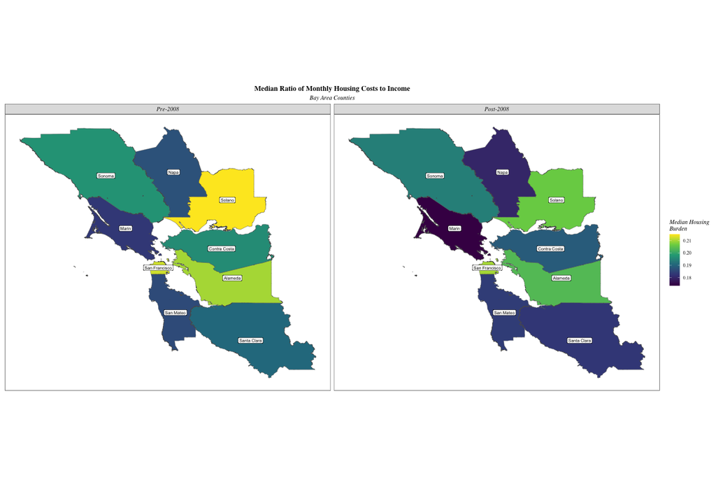

```python
%%R -w 1200 -h 800
ggplot(data = sf::st_as_sf(full_map, wkt = "the_geom")) +
    geom_sf(aes(fill = median_housing_burden)) +
    geom_sf_label(aes(label = COUNTY), size = 2.5, color = 'black') +
    facet_wrap(~post2008,
             labeller = labeller(post2008 = c("0" = "Pre-2008", "1" = "Post-2008"))) +
  scale_fill_viridis_c(name = "Median Housing\nBurden") +
  theme_bw() +
  labs(title = "Median Ratio of Monthly Housing Costs to Income", subtitle = "Bay Area Counties") +
  theme(
    plot.title = element_text(size = 12, face = "bold", hjust = 0.5, family = 'serif'),
    plot.subtitle = element_text(size = 10, hjust = 0.5, family = 'serif', face = 'italic'),
    panel.grid.major = element_blank(),
    panel.grid.minor = element_blank(),
    legend.position = "right",
    legend.title = element_text(size = 10, family = 'serif', face = 'italic'),
    legend.text = element_text(size = 8, family = 'serif'),
    axis.text = element_blank(),
    axis.ticks = element_blank(),
    axis.title = element_blank(),
    strip.background = element_rect(fill = 'gray88'),
    strip.text = element_text(size = 10, family = 'serif', face = 'italic')
  )
```

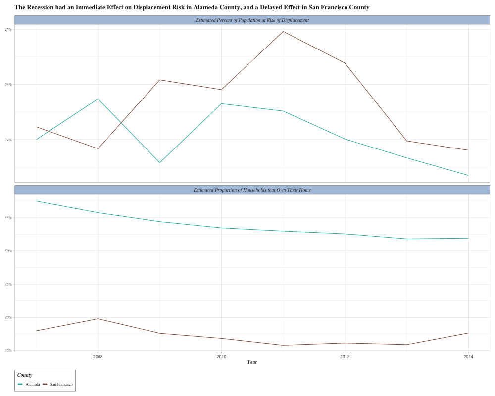

```python
%%R -w 1000 -h 800
acs_df %>%
    filter(name %in% c('Alameda', 'San Francisco')) %>%
    group_by(YEAR, name) %>%
    pivot_longer(
        cols = c('ownership', 'displacement_risk'),
        names_to = "variable",
        values_to = "value"
    ) %>%
    mutate(
        variable = if_else(variable == "ownership", "Estimated Proportion of Households that Own Their Home", "Estimated Percent of Population at Risk of Displacement")
    ) %>%
    ungroup() %>%
    ggplot(aes(x = YEAR)) +
    geom_path(aes(y = value, color = name)) +
    labs(
        title = 'The Recession had an Immediate Effect on Displacement Risk in Alameda County, and a Delayed Effect in San Francisco County',
        x = "Year",
        color = "County",
    ) +
    facet_wrap(~variable, nrow = 2, scales = "free_y") +
    scale_color_manual(labels = c("Alameda", "San Francisco"), values = c("lightseagreen", "lightsalmon4")) +
    scale_y_continuous(labels = scales::label_percent(scale = 100)) +
    theme_light() +
    guides(color = guide_legend(override.aes = list(linewidth = 1.2))) +
    theme(
        plot.title = element_textbox_simple(size = 13, color = 'gray10', hjust = 0, face = 'bold', width = 0.75, family = 'serif', margin = margin(b = 10)),
        strip.text = element_text(size = 10, face = 'italic',  color = 'gray20', family = 'serif'),
        strip.background = element_rect(fill = "lightsteelblue", color = "gray20", linewidth = 0.35),
        axis.title.x = element_text(size = 10, color = 'gray20', face = 'bold.italic',  family = 'serif'),,
        axis.title.y = element_blank(),
        axis.text.y = element_text(size = 8, face = 'italic', family = 'serif'),
        legend.title = element_text(size = 10, color = 'black', family = 'serif', face = 'bold.italic'),
        legend.title.position = "top",
        legend.text = element_text(size = 8, color = 'black', family = 'serif'),
        legend.direction = "horizontal",
        legend.position = "bottom",
        legend.justification = c(0, 0),
        legend.key.width = unit(0.4, "cm"),
        legend.key.spacing.x = unit(0.15, "cm"),
        legend.key.spacing.y = unit(0.15, "cm"),
        legend.background = element_rect(fill = "white", color = "gray20", linewidth = 0.25),
        plot.margin = margin(t = 10, r = 10, b = 10, l = 10),
    )
```

Looking at the proportions of each counties' populations at risk for displacement, we can see that San Francisco county follows the trends in Alameda county with a one year delay. I would hypothesize that this is a result of differences between the counties's rates of home-ownership. Before the crash, Alameda county had a higher proportion of home owners, whereas San Francisco had a larger proportion of renters. The recession had an immediate impact on people's abilities to pay their mortgages, but not as much on the rental market. However, as more people were displaced, the rental market became more competitive, and rent prices increased. That would explain why Alameda county sees an immediate effect on displacement risk, and San Francisco county sees a delayed effect.

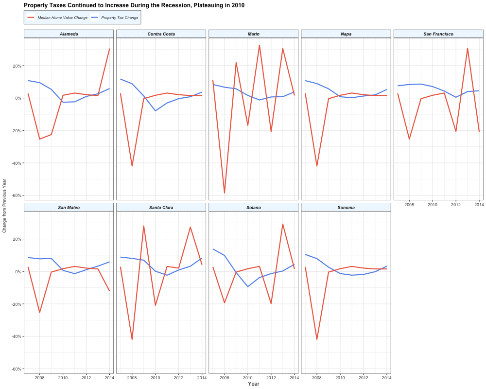

```python
%%R -w 1000 -h 800
ggplot(acs_df, aes(x = YEAR)) +
    geom_path(aes(y = tax_change, color = "Property Tax Change"), linewidth = 1) +
    geom_path(aes(y = median_hval_change, color = "Median Home Value Change"), linewidth = 1) +
    facet_wrap(~name, nrow = 2) +
    labs(
        title = "Property Taxes Continued to Increase During the Recession, Plateauing in 2010",
        x = "Year",
        y = "Change from Previous Year",
    ) +
    scale_y_continuous(labels = scales::label_percent(scale = 1)) +
    theme_bw() +
    scale_color_manual(values = c("coral2", "cornflowerblue")) +
    theme(
        plot.title = element_text(size = 12, hjust = 0, margin = margin(b = 5), face = 'bold'),
        strip.text = element_text(size = 9, face = "bold.italic"),
        strip.background = element_rect(fill = "aliceblue", color = "gray20"),
        axis.title.y = element_text(size = 9, color = "gray20", margin = margin(r = 10)),
        legend.position = "top",
        legend.justification = c(0, 0),
        legend.title = element_blank(),
        legend.text = element_text(size = 8, face = "italic", color = "gray20"),
        legend.background = element_rect(fill = 'aliceblue', color = "gray20", linewidth = 0.25),
    )
```

```python
%%R
peaks <- data.frame(indiv_acs %>%
    group_by(displacement_risk) %>%
    reframe(
        density = density(HHINCOME, na.rm = TRUE)$y,
        x = density(HHINCOME, na.rm = TRUE)$x
    )) %>%
    filter(x < 100000) %>%
    group_by(displacement_risk) %>%
    slice_max(density, n = 2)

p1 <- round(peaks[1, 3]$x, 0)
p2 <- round(peaks[3, 3]$x, 0)
```

[output not shown]

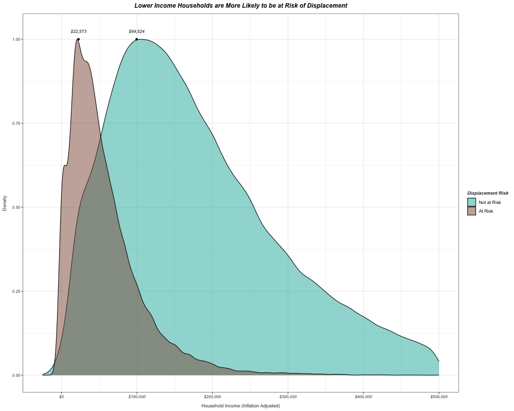

```python
%%R -w 1000 -h 800
indiv_acs %>%
    ggplot(aes(x = HHINCOME, fill = factor(displacement_risk), group = factor(displacement_risk))) +
    geom_density(aes(y = after_stat(scaled)), alpha = 0.5) +
    annotate("point", x = p1, y = 1, color = 'black', size = 1.5) +
    annotate('text', x = p1, y = 1.025, label = scales::dollar(p1), color = 'black', size = 3, fontface = 'italic') +
    annotate("point", x = p2, y = 1, color = 'black', size = 1.5) +
    annotate('text', x = p2, y = 1.025, label = scales::dollar(p2), color = 'black', size = 3, fontface = 'italic') +
    scale_fill_manual(values = c("lightseagreen", "lightsalmon4"), labels = c("Not at Risk", "At Risk")) +
    labs(
        title = "Lower Income Households are More Likely to be at Risk of Displacement",
        x = "Household Income (Inflation Adjusted)",
        y = "Density",
        fill = "Displacement Risk"
    ) +
    scale_x_continuous(labels = scales::label_dollar(scale = 1, prefix = "$"), limits = c(-25000, 5e5)) +
    theme_bw() +
    theme(
        plot.title = element_text(size = 12, hjust = 0.5, margin = margin(b = 10), face = 'bold.italic'),
        axis.title.x = element_text(size = 9, color = "gray20", margin = margin(t = 10)),
        axis.title.y = element_text(size = 9, color = "gray20", margin = margin(r = 10)),
        axis.text.x = element_text(size = 8, face = "italic", color = "gray20"),
        axis.text.y = element_text(size = 8, face = "italic", color = "gray20"),
        legend.title = element_text(size = 9, color = "gray20", face = "bold.italic"),
    )
```

Now looking at the individual-level data, we can see that households not at risk of displacement have a significantly higher distribution of income than households at risk.

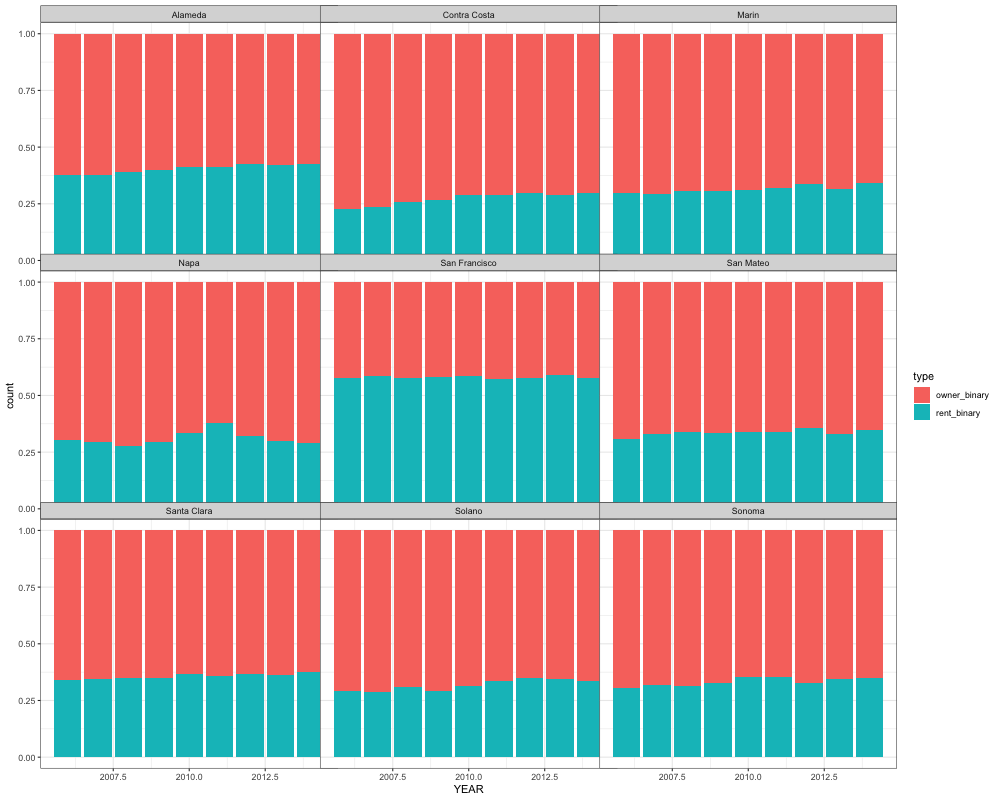

```python
%%R -w 1000 -h 800
indiv_acs %>%
    pivot_longer(
        cols = c('owner_binary', 'rent_binary'),
        names_to = 'type',
        values_to = 'value'
    ) %>%
    filter(value == 1) %>%
    ggplot(aes(x = YEAR, fill = type)) +
    geom_bar(position = 'fill') +
    facet_wrap(~name) +
    scale_color_manual(values = c("lightseagreen", "lightsalmon4")) +
    theme_bw() +
    theme(
        panel.spacing = unit(-1.25, "lines"),
    )
```

For the most part, the shares of renters and owners in San Francisco have been relatively stable - even during the recession. Alameda County likewise doesn't see a significant change in the share of renters or owners during the recession, but has a decreasing trend in the share of homeowners.

## Modeling

Before we can model the data, we need to check for multicollinearity. We will do this by calculating the correlation between all of the variables in our dataset.

[output not shown]

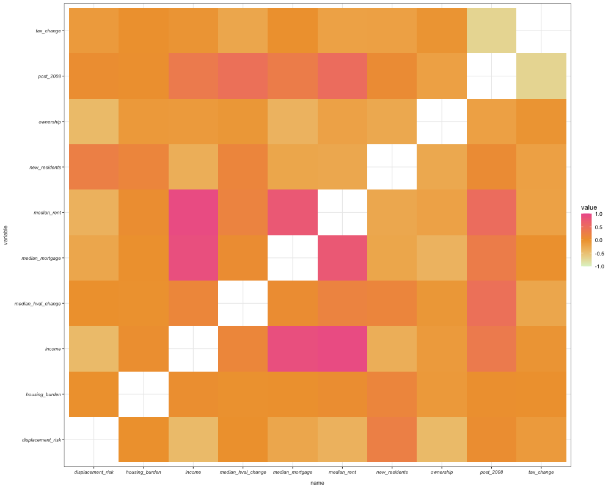

```python
%%R -w 1000 -h 800
cors <- data.frame(cor(acs_df %>%
    select(!c(name, YEAR)))) %>%
    mutate(variable = row.names(.)) %>%
    pivot_longer(cols = !variable, names_repair = 'check_unique') %>%
    filter(variable != name) %>%
    mutate(magnitude = abs(value)) %>%
    arrange(desc(magnitude))

ggplot(cors, aes(x = variable, y = name, fill = value)) +
    geom_tile() +
    coord_flip() +
    scale_fill_gradient2(low = '#DFF2CB', mid = '#F0A13A', high = '#EE609A', midpoint = 0, limits = c(-1, 1)) +
    theme_bw() +
    theme(
        plot.title = element_text(size = 12, hjust = 0.5, margin = margin(b = 10)),
        axis.title.x = element_text(size = 9, color = "gray20", margin = margin(t = 10)),
        axis.title.y = element_text(size = 9, color = "gray20", margin = margin(r = 10)),
        axis.text.x = element_text(size = 8, face = "italic", color = "gray20"),
        axis.text.y = element_text(size = 8, face = "italic", color = "gray20")
    )
```

```python
%%R
asf <- acs_df %>%
    filter(name %in% c('Alameda', 'San Francisco'))

model_fe <- glm(displacement_risk ~ ownership + median_hval_change + median_rent + tax_change + new_residents + factor(name) + post_2008, data = asf, family = binomial(link = "logit"))

coeftest(model_fe, vcov = vcovHC(model_fe, type = "HC1"))
```

```
z test of coefficients:
```

```
                             Estimate  Std. Error z value Pr(>|z|)
(Intercept)               -1.5757e+00  1.5463e+00 -1.0190  0.30820
ownership                 -1.2569e-01  2.5693e+00 -0.0489  0.96098
median_hval_change        -8.3986e-04  1.3628e-03 -0.6163  0.53770
median_rent               -6.2148e-06  1.0716e-04 -0.0580  0.95375
tax_change                -2.1079e-03  6.2067e-03 -0.3396  0.73414
new_residents              3.3595e+00  1.9996e+00  1.6801  0.09294 .
factor(name)San Francisco  5.7372e-02  4.3466e-01  0.1320  0.89499
post_2008                  8.1644e-03  1.0726e-01  0.0761  0.93933
---
Signif. codes:  0 ‘***’ 0.001 ‘**’ 0.01 ‘*’ 0.05 ‘.’ 0.1 ‘ ’ 1
```

```
In addition: Warning message:
In eval(family$initialize) : non-integer #successes in a binomial glm!
```

```python
%%R
model_fe2 <- lm(displacement_risk ~ ownership + median_hval_change + median_rent + tax_change + new_residents + factor(name) * post_2008, data = asf)

fe_coeftest <- coeftest(model_fe2, vcov = vcovHC(model_fe2, type = "HC1", save = TRUE))
fe_coeftest
```

[output not shown]

This model includes an interaction term between county and post-2008; this addition improved the model's fit significantly, and more of the coefficients are statistically significant. The most significant coefficient is negative, and for median rent -- this suggests that counties with higher median rents are less likely to experience displacement. This could just be a result of self-selection, as counties with higher rents are also likely to have higher incomes. The model also indicates that San Francisco experienced higher rates of displacement after the recession, while overall displacement rates after 2008 are expected to be lower. Additionally, the individual terms for San Francisco and post-2008 are both negative, but their interaction term is positive. This suggests that the recession had a fundamental impact on housing in San Francisco.

```python
%%R
property_tax_model <- lm(tax_change ~ post_2008 + median_hval_change + new_residents, data = acs_df)
print(summary(property_tax_model))
```

[output not shown]

```python
%%R
rent_model <- lm(median_rent ~ post_2008 + tax_change * new_residents, data = acs_df)
print(summary(rent_model))
```

[output not shown]

As a reminder, property taxes (for residences) in California only change when the property's value is assessed - usually only when selling or refinancing. But similarly, if a property is purchased at below market value, the property tax will be lower.

**Results**

This analysis found that displacement risk in Alameda County rose sharply immediately following the market crash, while San Francisco didn’t see a significant increase for another year. Comparing this trend with homeownership rates in both counties makes it clearer why this lag occurred; Alameda’s higher homeownership rates made it more vulnerable to foreclosures and predatory loan practices, which caused an immediate rise in displacement risk when people lost their jobs or fell behind on mortgage payments. San Francisco’s rental-dominated housing market, on the other hand, initially insulated renters from the direct consequences of the recession. However, as more and more displaced homeowners turned to renting, competition in the housing market grew, driving up rents and eventually raising the rate of displacement risk in San Francisco.

A somewhat unexpected finding was a strong negative association between median rent and displacement risk, suggesting that increases in rent decrease the risk of displacement. However, a closer look indicates that this outcome could be reflecting a form of self-selection, where more affluent households – who generally face a lower risk of displacement – tend to cluster in higher-priced areas.